# Tratamiento de Valores Faltantes y Detección de Outliers

HINOSTROZA TENORIO, Yeferson

2025-11-17

# Introducción

Cuando trabajamos con datos en la vida real, casi siempre nos encontramos con dos problemas comunes: datos que faltan y valores extremos que no encajan con el resto. Estos problemas son completamente normales y le pasan a todo el mundo que trabaja con datos.

Imagina que estás haciendo una encuesta y algunas personas no responden todas las preguntas. O piensa en medir la altura de un grupo de personas y alguien por error anotó 250 cm en lugar de 150 cm. Estas situaciones son ejemplos de datos faltantes y outliers.

En esta monografía vamos a aprender qué son estos problemas, por qué aparecen y cómo podemos solucionarlos de manera práctica.

# Valores Faltantes

## ¿Qué son los valores faltantes?

Los valores faltantes son simplemente espacios vacíos en nuestros datos. En R aparecen como `NA` (Not Available). Es como tener un formulario donde algunas casillas quedaron en blanco.

Por ejemplo, si tenemos datos de estudiantes:

```r
estudiantes <- data.frame(
  nombre = c("Ana", "Luis", "María", "Carlos"),
  edad = c(20, NA, 22, 21),
  nota = c(85, 90, NA, 88)
)

print(estudiantes)
```

```
##   nombre edad nota
## 1    Ana   20   85
## 2   Luis   NA   90
## 3  María   22   NA
## 4 Carlos   21   88
```

Aquí vemos que no sabemos la edad de Luis ni la nota de María.

## ¿Por qué faltan datos?

Los datos pueden faltar por varias razones:

**Razones técnicas:** A veces los sensores fallan, los archivos se corrompen o hay errores al copiar información de un lugar a otro.

**Razones humanas:** Las personas olvidan llenar campos, no quieren compartir información personal o simplemente se saltan preguntas que les parecen incómodas.

**Razones del diseño:** Algunas preguntas solo aplican para ciertas personas. Por ejemplo, si preguntas “¿cuántos hijos tienes?” a personas sin hijos, esa casilla podría quedar vacía.

## Tipos de valores faltantes

No todos los datos faltantes son iguales. Entender el tipo nos ayuda a decidir qué hacer:

### Faltantes completamente al azar (MCAR)

Estos datos faltan sin ningún patrón. Es pura casualidad. Por ejemplo, si tu computadora se apagó justo cuando ibas a guardar algunos datos y perdiste información aleatoria.

### Faltantes al azar (MAR)

Aquí sí hay un patrón, pero está relacionado con otras variables que sí tenemos. Por ejemplo, las personas mayores tienden a no responder preguntas sobre tecnología, pero sí sabemos su edad.

### Faltantes no al azar (MNAR)

Los datos faltan por una razón relacionada con el valor mismo que falta. Por ejemplo, las personas con ingresos muy altos prefieren no revelar su salario.

## Detectando valores faltantes

Antes de hacer algo, necesitamos saber dónde están los problemas:

```r
# Crear datos de ejemplo
set.seed(123)
datos <- data.frame(
  edad = sample(c(18:65, NA), 100, replace = TRUE),
  ingreso = sample(c(1000:5000, NA), 100, replace = TRUE),
  educacion = sample(c("Primaria", "Secundaria", "Universidad", NA), 100, replace = TRUE)
)

# Ver cuántos NA hay en cada columna
colSums(is.na(datos))
```

```
##      edad   ingreso educacion
##         1         0        19
```

```r
# Ver el porcentaje de datos faltantes
porcentaje_na <- colMeans(is.na(datos)) * 100
print(round(porcentaje_na, 2))
```

```
##      edad   ingreso educacion
##         1         0        19
```

### Visualizando datos faltantes

Las imágenes nos ayudan a entender mejor:

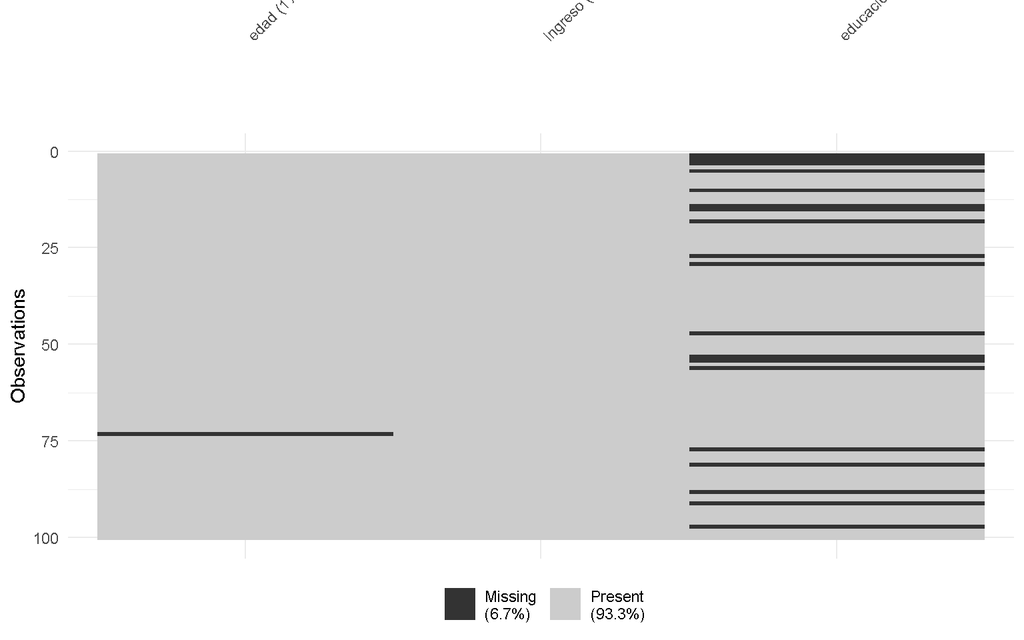

```r
# Patrón de valores faltantes
vis_miss(datos)
```

## Estrategias para manejar valores faltantes

### Opción 1: Eliminar los datos faltantes

La forma más simple es borrar las filas con datos faltantes:

```r
# Eliminar filas con cualquier NA
datos_completos <- na.omit(datos)

# Ver cuántos datos perdimos
cat("Datos originales:", nrow(datos), "filas\n")
```

```
## Datos originales: 100 filas
```

```r
cat("Datos después de eliminar NA:", nrow(datos_completos), "filas\n")
```

```
## Datos después de eliminar NA: 80 filas
```

```r
cat("Perdimos:", nrow(datos) - nrow(datos_completos), "filas")
```

```
## Perdimos: 20 filas
```

**Cuándo usar esto:** Solo cuando tienes muchos datos y los faltantes son pocos (menos del 5%). Si no, puedes perder información valiosa.

**Ventajas:** Es rápido y simple.

**Desventajas:** Pierdes información y puedes crear sesgos en tus resultados.

### Opción 2: Rellenar con un valor simple

Podemos llenar los huecos con un valor que tenga sentido:

```r
datos_imputados <- datos

# Rellenar edad con la edad promedio
datos_imputados$edad[is.na(datos_imputados$edad)] <-
  mean(datos_imputados$edad, na.rm = TRUE)

# Rellenar ingreso con la mediana
datos_imputados$ingreso[is.na(datos_imputados$ingreso)] <-
  median(datos_imputados$ingreso, na.rm = TRUE)

# Rellenar educación con el valor más común
moda_educacion <- names(sort(table(datos_imputados$educacion),
                             decreasing = TRUE))[1]
datos_imputados$educacion[is.na(datos_imputados$educacion)] <-
  moda_educacion

# Verificar
cat("NAs restantes:", sum(is.na(datos_imputados)))
```

```
## NAs restantes: 0
```

**Cuándo usar esto:** Para análisis exploratorios rápidos o cuando los datos faltantes son muy pocos.

**Ventajas:** Muy fácil de implementar y mantiene el tamaño de tus datos.

**Desventajas:** Reduce la variabilidad natural de los datos y puede distorsionar las relaciones entre variables.

### Opción 3: Imputación múltiple (método avanzado)

Este método es más sofisticado. Usa las relaciones entre variables para adivinar los valores faltantes de forma inteligente:

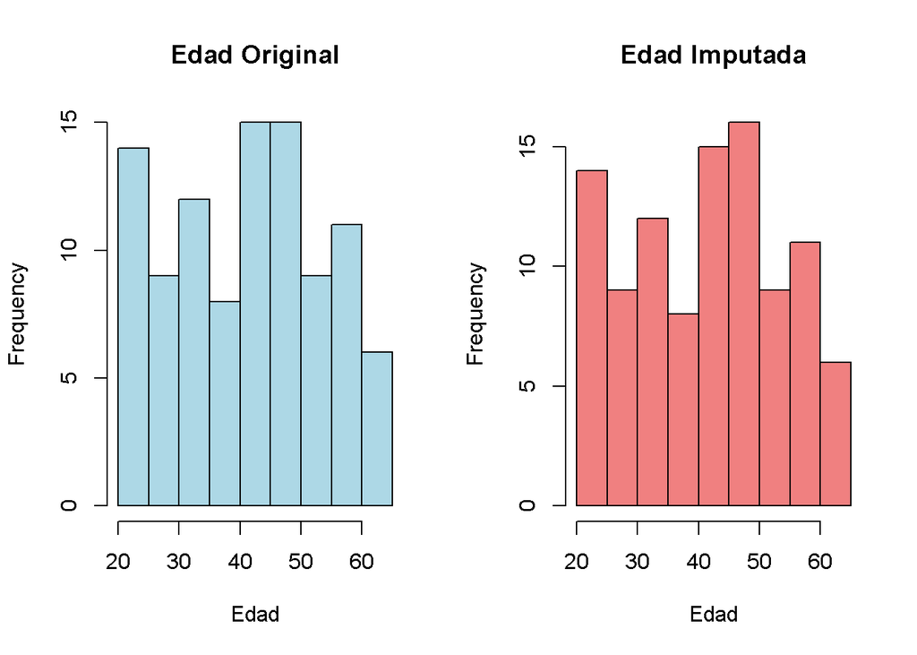

```r
# Preparar datos para MICE
datos_numericos <- datos
datos_numericos$educacion <- as.factor(datos_numericos$educacion)

# Imputación múltiple
imputacion <- mice(datos_numericos, m = 5, method = 'pmm', seed = 123,
                   print = FALSE)

# Obtener un conjunto de datos completo
datos_mice <- complete(imputacion, 1)

# Comparar distribuciones
par(mfrow = c(1, 2))
hist(datos$edad, main = "Edad Original", xlab = "Edad", col = "lightblue")
hist(datos_mice$edad, main = "Edad Imputada", xlab = "Edad", col = "lightcoral")
```

**Cuándo usar esto:** Cuando tienes datos importantes con bastantes valores faltantes (entre 5% y 40%) y necesitas resultados precisos.

**Ventajas:** Preserva las relaciones entre variables y la variabilidad natural de los datos.

**Desventajas:** Es más complejo y requiere más tiempo de cálculo.

# Detección de Outliers

## ¿Qué son los outliers?

Los outliers (valores atípicos) son datos que están muy alejados del resto. Son como una persona de 2 metros de altura en un salón de niños de primaria: técnicamente es un dato válido, pero definitivamente llama la atención.

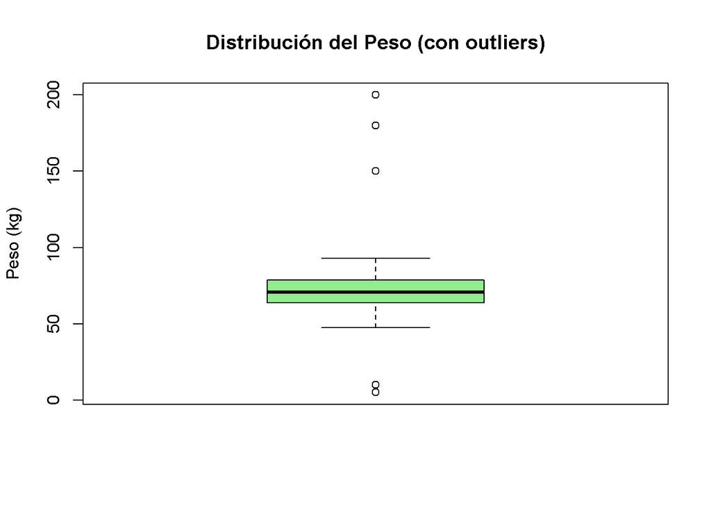

```r
# Crear datos con outliers
set.seed(456)
datos_outliers <- data.frame(
  id = 1:100,
  peso = c(rnorm(95, mean = 70, sd = 10), 150, 180, 200, 5, 10)
)

# Visualizar
boxplot(datos_outliers$peso, main = "Distribución del Peso (con outliers)",
        ylab = "Peso (kg)", col = "lightgreen")
```

## ¿Por qué aparecen los outliers?

Los outliers pueden aparecer por varias razones:

**Errores de medición:** Alguien escribió mal un número. En vez de 70 kg, escribió 700 kg.

**Errores de entrada de datos:** Al escribir en la computadora se presionaron teclas extra.

**Valores reales extremos:** A veces son datos verdaderos pero inusuales. Por ejemplo, el ingreso de un millonario en una encuesta de ingresos promedio.

**Variabilidad natural:** En algunos fenómenos, los valores extremos son normales y esperados.

## Métodos para detectar outliers

### Método 1: Visualización con boxplot

La caja con bigotes es una forma visual muy útil:

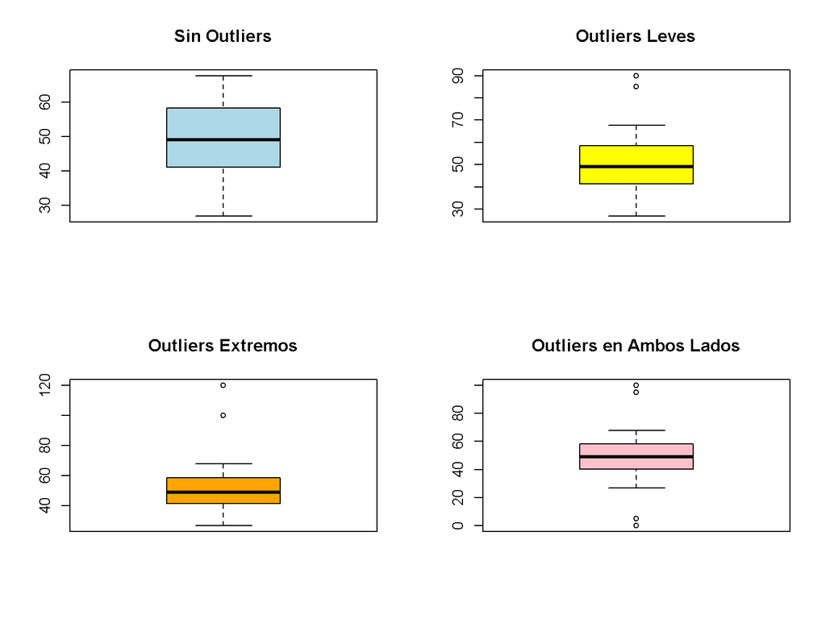

```r
par(mfrow = c(2, 2))

# Datos sin outliers
datos_normales <- rnorm(100, mean = 50, sd = 10)
boxplot(datos_normales, main = "Sin Outliers", col = "lightblue")

# Datos con outliers leves
datos_leves <- c(datos_normales, 85, 90)
boxplot(datos_leves, main = "Outliers Leves", col = "yellow")

# Datos con outliers extremos
datos_extremos <- c(datos_normales, 100, 120)
boxplot(datos_extremos, main = "Outliers Extremos", col = "orange")

# Datos con outliers en ambos lados
datos_ambos <- c(datos_normales, 0, 5, 95, 100)
boxplot(datos_ambos, main = "Outliers en Ambos Lados", col = "pink")
```

En el boxplot:

- La caja muestra donde está el 50% central de los datos
- La línea del medio es la mediana
- Los puntos fuera de los “bigotes” son posibles outliers

### Método 2: Rango intercuartílico (IQR)

Este es el método matemático detrás del boxplot:

```r
# Calcular IQR
Q1 <- quantile(datos_outliers$peso, 0.25)
Q3 <- quantile(datos_outliers$peso, 0.75)
IQR_valor <- Q3 - Q1

# Calcular límites
limite_inferior <- Q1 - 1.5 * IQR_valor
limite_superior <- Q3 + 1.5 * IQR_valor

cat("Límite inferior:", limite_inferior, "\n")
```

```
## Límite inferior: 41.80965
```

```r
cat("Límite superior:", limite_superior, "\n")
```

```
## Límite superior: 100.704
```

```r
# Identificar outliers
outliers_iqr <- datos_outliers$peso < limite_inferior |
                datos_outliers$peso > limite_superior

cat("\nNúmero de outliers detectados:", sum(outliers_iqr), "\n")
```

```
##
## Número de outliers detectados: 5
```

```r
cat("Valores outliers:", datos_outliers$peso[outliers_iqr])
```

```
## Valores outliers: 150 180 200 5 10
```

### Método 3: Z-score (puntaje estandarizado)

Este método mide qué tan lejos está cada dato del promedio:

```r
# Calcular Z-scores
z_scores <- scale(datos_outliers$peso)

# Los datos con |Z-score| > 3 son outliers extremos
outliers_z <- abs(z_scores) > 3

cat("Outliers por Z-score (|Z| > 3):", sum(outliers_z), "\n")
```

```
## Outliers por Z-score (|Z| > 3): 3
```

[figure not shown]

```r
# Visualizar
plot(datos_outliers$id, z_scores,
     main = "Z-scores de los Datos",
     xlab = "ID", ylab = "Z-score",
     col = ifelse(outliers_z, "red", "blue"),
     pch = 19)
abline(h = c(-3, 3), col = "red", lty = 2)
legend("topright", c("Normal", "Outlier"),
       col = c("blue", "red"), pch = 19)
```

**Interpretación del Z-score:**

- Z-score entre -2 y 2: dato normal (95% de los datos)
- Z-score entre -3 y 3: dato aceptable (99.7% de los datos)
- Z-score mayor que 3 o menor que -3: posible outlier

### Método 4: Método MAD (Desviación Absoluta Mediana)

Este método es más robusto que el Z-score porque no se afecta tanto por los outliers mismos:

```r
# Calcular MAD
mediana <- median(datos_outliers$peso)
mad_valor <- mad(datos_outliers$peso)

# Calcular modified Z-scores
mad_scores <- abs(datos_outliers$peso - mediana) / mad_valor

# Identificar outliers (usualmente se usa 3.5 como umbral)
outliers_mad <- mad_scores > 3.5

cat("Outliers por método MAD:", sum(outliers_mad), "\n")
```

```
## Outliers por método MAD: 5
```

```r
cat("Valores outliers:", datos_outliers$peso[outliers_mad])
```

```
## Valores outliers: 150 180 200 5 10
```

## ¿Qué hacer con los outliers?

Una vez que identificamos outliers, tenemos varias opciones:

### Opción 1: Investigar primero

Antes de hacer cualquier cosa, investiga:

```r
# Ver los outliers en contexto
datos_con_flag <- datos_outliers
datos_con_flag$es_outlier <- outliers_iqr

# Mostrar outliers
cat("Outliers detectados:\n")
```

```
## Outliers detectados:
```

```r
print(datos_con_flag[datos_con_flag$es_outlier, ])
```

```
##      id peso es_outlier
## 96   96  150       TRUE
## 97   97  180       TRUE
## 98   98  200       TRUE
## 99   99    5       TRUE
## 100 100   10       TRUE
```

Pregúntate:

- ¿Es un error obvio de escritura?
- ¿Puede ser un valor real?
- ¿Afecta mucho mis resultados?

### Opción 2: Eliminar outliers

Si estás seguro de que son errores:

```r
# Eliminar outliers
datos_sin_outliers <- datos_outliers[!outliers_iqr, ]

# Comparar
cat("Datos originales:", nrow(datos_outliers), "observaciones\n")
```

```
## Datos originales: 100 observaciones
```

```r
cat("Datos sin outliers:", nrow(datos_sin_outliers), "observaciones\n")
```

```
## Datos sin outliers: 95 observaciones
```

```r
cat("Diferencia:", nrow(datos_outliers) - nrow(datos_sin_outliers),
    "observaciones eliminadas")
```

```
## Diferencia: 5 observaciones eliminadas
```

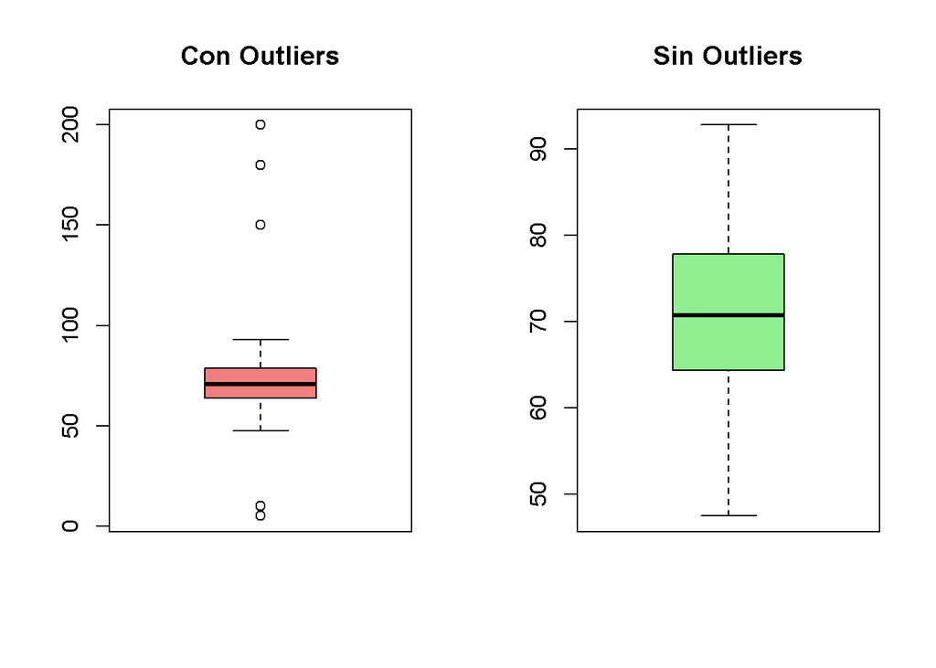

```r
# Visualizar diferencia
par(mfrow = c(1, 2))
boxplot(datos_outliers$peso, main = "Con Outliers", col = "lightcoral")
boxplot(datos_sin_outliers$peso, main = "Sin Outliers", col = "lightgreen")
```

### Opción 3: Transformar outliers (winsorización)

En vez de eliminar, cambiamos los valores extremos por algo más razonable:

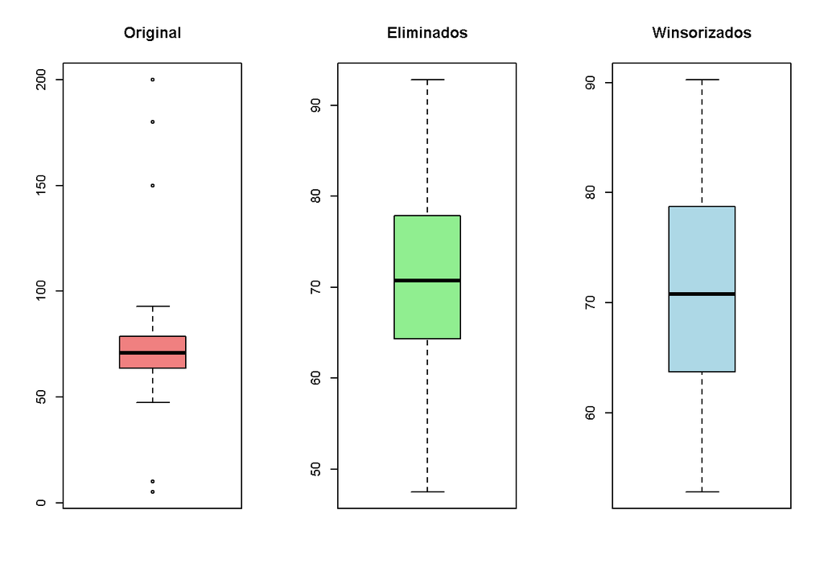

```r
# Función para winsorizar
winsorizar <- function(x, probs = c(0.05, 0.95)) {
  limites <- quantile(x, probs = probs, na.rm = TRUE)
  x[x < limites[1]] <- limites[1]
  x[x > limites[2]] <- limites[2]
  return(x)
}

# Aplicar winsorización
datos_winsor <- datos_outliers
datos_winsor$peso <- winsorizar(datos_winsor$peso)

# Comparar
par(mfrow = c(1, 3))
boxplot(datos_outliers$peso, main = "Original", col = "lightcoral")
boxplot(datos_sin_outliers$peso, main = "Eliminados", col = "lightgreen")
boxplot(datos_winsor$peso, main = "Winsorizados", col = "lightblue")
```

### Opción 4: Usar métodos robustos

En vez de cambiar los datos, usamos estadísticas que no se afectan por outliers:

```r
# Comparar media vs mediana
cat("Media (sensible a outliers):", mean(datos_outliers$peso), "\n")
```

```
## Media (sensible a outliers): 72.93725
```

```r
cat("Mediana (robusta a outliers):", median(datos_outliers$peso), "\n")
```

```
## Mediana (robusta a outliers): 70.78153
```

```r
# La mediana no cambia mucho con outliers
cat("\nSin outliers:\n")
```

```
##
## Sin outliers:
```

```r
cat("Media:", mean(datos_sin_outliers$peso), "\n")
```

```
## Media: 71.03921
```

```r
cat("Mediana:", median(datos_sin_outliers$peso), "\n")
```

```
## Mediana: 70.72856
```

# Caso Práctico Completo

Vamos a juntar todo lo aprendido con un ejemplo real:

```r
# Crear dataset realista
set.seed(789)
n <- 200

ventas <- data.frame(
  id = 1:n,
  edad_cliente = sample(c(18:70, NA), n, replace = TRUE),
  monto_compra = c(rnorm(190, 500, 150), 5000, 6000, rep(NA, 8)),
  tiempo_cliente = sample(c(1:10, NA), n, replace = TRUE),
  satisfaccion = sample(c(1:5, NA), n, replace = TRUE)
)

cat("=== ESTADO INICIAL ===\n")
```

```
## === ESTADO INICIAL ===
```

```r
cat("Dimensiones:", dim(ventas), "\n")
```

```
## Dimensiones: 200 5
```

```r
cat("NAs por columna:\n")
```

```
## NAs por columna:
```

```r
print(colSums(is.na(ventas)))
```

```
##             id   edad_cliente   monto_compra tiempo_cliente   satisfaccion
##              0              4              8             15             37
```

## Paso 1: Análisis exploratorio

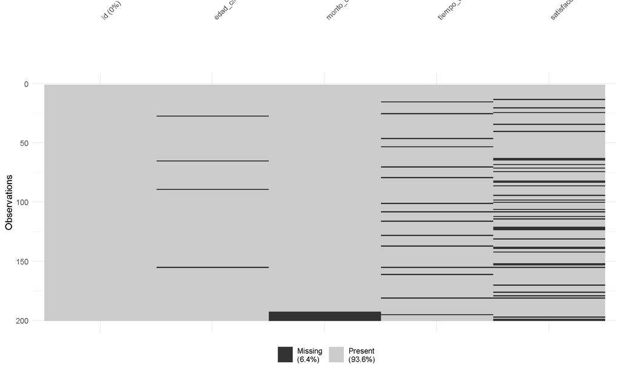

```r
# Visualizar datos faltantes
vis_miss(ventas)
```

```r
# Estadísticas descriptivas
summary(ventas)
```

```
##        id          edad_cliente    monto_compra    tiempo_cliente
##  Min.   :  1.00   Min.   :18.00   Min.   : 178.1   Min.   : 1.000
##  1st Qu.: 50.75   1st Qu.:32.00   1st Qu.: 427.1   1st Qu.: 3.000
##  Median :100.50   Median :44.00   Median : 528.1   Median : 6.000
##  Mean   :100.50   Mean   :44.67   Mean   : 583.1   Mean   : 5.919
##  3rd Qu.:150.25   3rd Qu.:57.25   3rd Qu.: 657.5   3rd Qu.: 8.000
##  Max.   :200.00   Max.   :70.00   Max.   :6000.0   Max.   :10.000
##                   NA's   :4       NA's   :8        NA's   :15
##   satisfaccion
##  Min.   :1.000
##  1st Qu.:2.000
##  Median :3.000
##  Mean   :2.988
##  3rd Qu.:4.000
##  Max.   :5.000
##  NA's   :37
```

## Paso 2: Tratar valores faltantes

```r
# Imputar valores faltantes
ventas_limpio <- ventas

# Edad: usar mediana
ventas_limpio$edad_cliente[is.na(ventas_limpio$edad_cliente)] <-
  median(ventas_limpio$edad_cliente, na.rm = TRUE)

# Tiempo cliente: usar media
ventas_limpio$tiempo_cliente[is.na(ventas_limpio$tiempo_cliente)] <-
  round(mean(ventas_limpio$tiempo_cliente, na.rm = TRUE))

# Satisfacción: usar moda
moda_sat <- as.numeric(names(sort(table(ventas_limpio$satisfaccion),
                                  decreasing = TRUE))[1])
ventas_limpio$satisfaccion[is.na(ventas_limpio$satisfaccion)] <- moda_sat

# Monto: decidir después de ver outliers
```

## Paso 3: Detectar y tratar outliers

```r
# Detectar outliers en monto_compra
Q1 <- quantile(ventas_limpio$monto_compra, 0.25, na.rm = TRUE)
Q3 <- quantile(ventas_limpio$monto_compra, 0.75, na.rm = TRUE)
IQR_val <- Q3 - Q1

limite_inf <- Q1 - 1.5 * IQR_val
limite_sup <- Q3 + 1.5 * IQR_val

outliers <- ventas_limpio$monto_compra < limite_inf |
            ventas_limpio$monto_compra > limite_sup

cat("Outliers detectados:", sum(outliers, na.rm = TRUE), "\n")
```

```
## Outliers detectados: 2
```

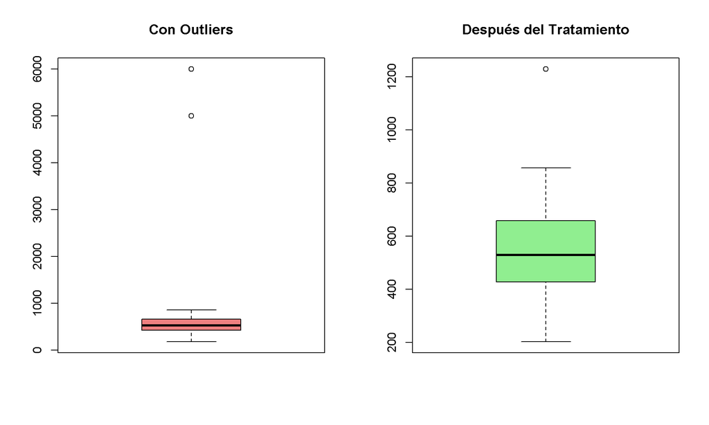

```r
# Visualizar
par(mfrow = c(1, 2))
boxplot(ventas_limpio$monto_compra, main = "Con Outliers",
        col = "lightcoral")

# Aplicar winsorización
ventas_limpio$monto_compra <- winsorizar(ventas_limpio$monto_compra,
                                          probs = c(0.01, 0.99))

boxplot(ventas_limpio$monto_compra, main = "Después del Tratamiento",
        col = "lightgreen")
```

## Paso 4: Imputar valores faltantes restantes

```r
# Ahora sí imputar monto_compra
ventas_limpio$monto_compra[is.na(ventas_limpio$monto_compra)] <-
  median(ventas_limpio$monto_compra, na.rm = TRUE)

cat("=== RESULTADO FINAL ===\n")
```

```
## === RESULTADO FINAL ===
```

```r
cat("NAs restantes:", sum(is.na(ventas_limpio)), "\n")
```

```
## NAs restantes: 0
```

```r
summary(ventas_limpio)
```

```
##        id          edad_cliente    monto_compra    tiempo_cliente
##  Min.   :  1.00   Min.   :18.00   Min.   : 202.0   Min.   : 1.000
##  1st Qu.: 50.75   1st Qu.:32.75   1st Qu.: 430.9   1st Qu.: 4.000
##  Median :100.50   Median :44.00   Median : 528.1   Median : 6.000
##  Mean   :100.50   Mean   :44.66   Mean   : 538.4   Mean   : 5.925
##  3rd Qu.:150.25   3rd Qu.:57.00   3rd Qu.: 651.8   3rd Qu.: 8.000
##  Max.   :200.00   Max.   :70.00   Max.   :1229.3   Max.   :10.000
##   satisfaccion
##  Min.   :1.000
##  1st Qu.:2.000
##  Median :4.000
##  Mean   :3.175
##  3rd Qu.:4.000
##  Max.   :5.000
```

## Paso 5: Comparar antes y después

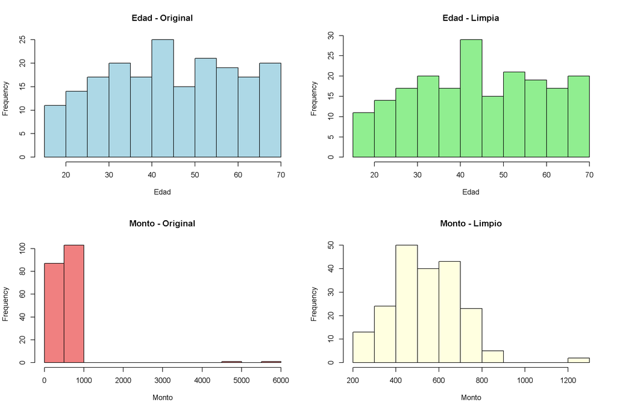

```r
par(mfrow = c(2, 2))

# Edad
hist(ventas$edad_cliente, main = "Edad - Original",
     col = "lightblue", xlab = "Edad")
hist(ventas_limpio$edad_cliente, main = "Edad - Limpia",
     col = "lightgreen", xlab = "Edad")

# Monto
hist(ventas$monto_compra, main = "Monto - Original",
     col = "lightcoral", xlab = "Monto")
hist(ventas_limpio$monto_compra, main = "Monto - Limpio",
     col = "lightyellow", xlab = "Monto")
```

# Recomendaciones Prácticas

## Para valores faltantes

1. **Siempre analiza primero:** No borres datos sin pensar. Investiga por qué faltan.
2. **Documenta tus decisiones:** Escribe qué hiciste y por qué. Tu yo del futuro te lo agradecerá.
3. **Usa el método apropiado:**
   - Pocos faltantes (< 5%): puedes eliminar
   - Faltantes moderados (5-20%): imputación simple
   - Muchos faltantes (> 20%): imputación múltiple o busca más datos
4. **Verifica el impacto:** Compara tus resultados con y sin imputación para ver si cambian mucho.

## Para outliers

1. **No elimines automáticamente:** Un outlier puede ser tu descubrimiento más importante.
2. **Investiga el contexto:** ¿Es un error o un fenómeno real interesante?
3. **Usa múltiples métodos:** Si varios métodos identifican el mismo outlier, probablemente sea real.
4. **Considera el análisis:**
   - Para promedios: los outliers afectan mucho
   - Para medianas: los outliers afectan poco
   - Para modelos predictivos: depende del modelo
5. **Reporta todo:** Di siempre cuántos outliers encontraste y qué hiciste con ellos.

# Conclusiones

Trabajar con datos faltantes y outliers es parte normal del análisis de datos. No hay una única forma correcta de manejarlos, todo depende de:

- Tu tipo de datos
- Tu objetivo de análisis
- El contexto de tu problema
- La cantidad de datos que tienes

Lo más importante es ser transparente, documentar tus decisiones y siempre verificar que tus resultados tengan sentido en el mundo real.

Recuerda: **los datos limpios no son perfectos, son apropiados para tu análisis.**

# Referencias y Recursos Adicionales

Para aprender más sobre estos temas:

- **Paquetes de R útiles:**
  - `naniar`: visualización de datos faltantes
  - `mice`: imputación múltiple
  - `VIM`: visualización de datos faltantes
  - `outliers`: detección de outliers
- **Conceptos clave:**
  - MCAR, MAR, MNAR: tipos de datos faltantes
  - IQR: rango intercuartílico
  - Z-score: puntaje estandarizado
  - Winsorización: técnica de transformación
- **Buenas prácticas:**
  - Siempre explora tus datos primero
  - Documenta cada paso de tu limpieza
  - Guarda versiones antes y después de la limpieza
  - Verifica que los resultados tengan sentido